# Exploring the BRFSS data

## Setup

### Load packages

```r
library(ggplot2)
library(dplyr)
```

### Load data

```r
load("brfss2013.RData")
```

## Part 1: Data

BFRSS is an abbreviation for Behavioral Risk Factor Surveillance System. It is a large US telephone survey regarding health-related rish behaviours, chronic health conditions, and use of preventive services.The survey started in 1983, and has continued since then. The data in the dataset given in this assignment are mostly from 2013, but 5682 of the 491775 observations are from 2014. I have not found an explanation for that, but suspect that the reason is that the phone interviews followed the protocol from 2013, but were conducted in 2014. There’s really no reason to pick the same date for both BRFSS’s new year and the calendars new year.

This is observational data, it is not the result of an experiment.

Calls were made 7 days of week, daytime and evenings, all through the year, according to a standard BRFSS procedure for rotation of calls. Although the data is collected continously, there are no follow-up interviews of known respondents. Even if we analyze data from several years, we cannot compare the answers of one individual from one year to the next.

The interviewers are usually professional telephone interviewers, and are given training specific to this survey before conducting interviews. They are using a computerized script while conducting the interview and record the answers on the computer in realtime.

Various control methods are used to make sure that the interviewers aren’t cheating or inventing data. Some methods used is: listening in on the interviewer, listening to both sides of the conversation, calling the respondent back to verify how the interviewer behaved, or simply analysing in bulk a particular interviewers data to see if frequencies vary significantly from the observations recorded by other interviewers.

The respondents are not paid for their time or effort, but are told that the interview is important for society. Every respondent is anonymous. Due to anonymity, there can be no controls in place to check that the respondents aren’t lying. Since this is a health survey, some of the questions might be considered of a personal nature, and there is a risk that respondents brag, lie, or omit things. Respondents are allowed to refuse individual questions, and this will be coded by the interviewer as “refused”.

The survey is done in US states and territories, including District of Columbia, Puerto Rico, Guam, US Virgin Islands, all of them hereafter known simply as “states”. Each state organizes their own survey, and funding can have some influence of sample size and how the survey is organized. There is a core set of questions that every state must ask every year, some questions that vary from year to year, and some questions that each state can opt to add themselves. Dividing the survey into states (or other geographical areas, or groups of other kinds) is known as *stratified sampling*.

To find respondents, a computer dials random digits, and a paid interviewer who interviews or tries to interview a person in the household corresponding to the dialed telephone number. In other words, within each state (or strata), one could in theory use simple random sampling, and a few states do. Most of the states use more advanced techniques to obtain a representative sample. In any case, since the observations are randomised, this is an example of *stratified random sampling*, albeit a complicated one.

Several states used stratified sampling for different geographical regions within state borders. Also, cell phone users and landline users are treated as different strata: Some strata defined in the survey overview are very technical: For landlines, the numbers divided into two strata known as *high-density* or *medium-density* corresponding to how many househould numbers are allocated on each 100-block of numbers, and for cell phones a similar but more complex system is used for 1000-banks of cell phone numbers in a dedicated area code and exchange.

Not everyone that answers the phone is interviewed. In order to be eligible for the survey, the respondent must confirm that they answer from a phone with the same number the interviewer dialled, confirm that they are in a private residence or college housing, confirm that they live in this state, and confirm to be above 18. The survey is deliberately not trying to collect data from children, homeless, people in institutions, or people who are at work or somewhere else than in a private residence or college housing when called. If there are several adults in the house, a random person is selected. A person answering a cell phone will only be interviewed if the interviewee responds that they receive 90% or more of their calls on cellphones.

These restrictions might seem arbitrary, but they exist in order to produce a more representative sample then you would get if you simply interviewed anyone willing to talk. Since numbers are dialled randomly, persons who have more than one phone will also be overrepresented, and people sharing a single phone will be underrepresented.

*Design weights* are weights given to observations, that are known at design time of the study. This includes sample size in each state, number of phones, and number of adults in household. The formula is simple:

$$\textrm{Design Weight} = \textrm{Stratum Weight}
\cdot
\frac{\textrm{Number of adults in household}}{\textrm{Number of phones}}$$
where
$$\textrm{Stratum Weight} = \frac{\textrm{Population in stratum}}{\textrm{Sample size of stratum}\cdot\textrm{Total population}}$$
In additition to geographic areas, a stratum in this survey also involves technicalities around random-digit dialling of landlines and cell phones.

This formula alone doesn’t necessary give a representative sample. Typically you will get an overrepresentation of people near phones, with lots of time, and who like to talk. And an underrepresentation of people away from phones, who are busy, and dislike talking to strangers on the phone. You can’t really control for this when doing a phone interview,

Controlling against people being a way from the phone, is obviously not possible. But something that *is* possible, is to compare every observation against known population data, and use this to raise or lower that observations weight. For this survey, the following categories are used: age, sex, categories of ethnicity, geographic regions within states, marital status, education level, home ownership and type of phone ownership. The observations are weighted by a computer program using a statistical method called *iterative proportional fitting*, or *raking*

Luckily, one does not have to understand *raking* or the technicalities with random digit dialling in detail to make meaningful inferences from the data. The result of the analysis is included in the dataset as two variables> : **_LLCPWT** and **_CLLCPWT** corresponding to the respondents weight, and the respondents childs weight. Due to R variable naming rules, in our dataset, these variables are called **X_llcpwt2** **X_llcpwt**. To make inferences from the data, each observations variables should be weighted by one of these weights (depending on whether the variable is about the adult itself or the child)

There’s another reason why *raking* is done before publishing. Some of the demographic data collected are only used for calculating weights of observations, but since it could potentially help identify respondents, it is removed from the dataset before publishing. So even if we wanted to, we couldn’t redo the *raking*.

A weakness with the given dataset is that when variables are missing, we don’t know why: Did the respondent refuse to answer this particular question? Or was the respondent unable to answer this question? Or was there some other fault, maybe the interview abrubtly ended, or the interviewer forgot to ask a question or record the answer?

The codebook includes the frequency of “don’t know”, “refused”, and “missing” for each question, but it is impossible to know for a particular missing variable in a particular observation what the reason for the missing variable is. In contrast to the included *R* dataset, the BRFSS dataset published in *stata* format includes the original coding. If the reason for missing values is of interest when analysing data, a possible solution would be to import that stata-formatted dataset into R instead of using the one supplied in R-format.

More importantly, the survey is deliberately not universal to all americans. While it in some respects tries very hard to be so, by e.g. including every state and territory, interviewing huge amounts of people, and using advanced statistical techniques. In some respects it strangely enough tries very hard *not* to be universal, and deliberately excludes people in instutions (jail, military, etc), as well as homeless people and other people without phones.

## Part 2: Research questions

**Research quesion 1:**

Do former smokers exercise more than active smokers or non-smokers?

This question can potentially help understand if people primarily stop smoking for health-related reasons, or if other factors, such as social pressure is more important. If smokers quit for health-related reasons, we can also try to discover if the increased interest in personal health is short-lived or permanent.

**Research quesion 2:**

Do people with high BMI have lower education level or income level?

Even if we find such a correlation, we still have multiple explanations: There could be a confounder, an external variable, that causes people to both lower their ambitions in school and the workplace, and also causes them to eat more. There could also be outright discrimination, that being overweight cases teachers to give you lower grades, and bosses to promote someone else. It is also possible that lack of success in school and work causes people to eat more. Asking this question won’t help answer these questions, but before we start looking for an explanation, we must at least figure out if the effect even exists.

bmi5cat educa employ1

**Research quesion 3:**

Are certain demographic groups weighted higher in the survey? Race group? Home Owners or Home Renters? Employment status?

This could possibly indicate that certain demographic groups are more likely to have several adults in the household. Or that there are other reasons that they are underrepresented in the survey. If we find obvious patterns like this, the next step would be to find out why, and possibly update the survey method to be more representative before raking.

raceg renthom1 employ1 X_llcpwt2

## Part 3: Exploratory data analysis

**Research question 1:**

The numbers in *exeroft1*, *exeroft2* and *strength* are coded in a strange way, to allow the respondent to give answers per week or per month. This is hard to work with, so I create a function to convert all answers to times per week.

The total excercise sessions per week is a sum of three variables, if any of these variables are *NA*, the result will also be *NA*. It is reasonable to assume that most people would like to brag. In other words, those who do some form or regular exercise regularly would answer this question. Likewise people not exercising regularly would be the ones most likely to not answer. Therefore I substitute *NA* with zeroes. The full dataset also includes number of minutes per exercise session, and type of activity. Taking this into account would make the analysis more accurate, but much more difficult. It is therefore ignored. Instead, only the count of exercise sessions per week is used.

```r
exer_per_week = function(n) {
  ifelse(is.na(n),
         0,
         ifelse(n > 200,
                (n %% 200) / 4.35,
                ifelse(n > 100,
                       (n %% 100),
                       0)))
}
```

The observations will be classified into three categories *current_smoker*, *former_smoker*, and *nonsmoker*’s.

If someone claim to never have smoked more than 100 cigarettes in their life, or that they never have smoked regularly, they are a *nonsmoker*. If it’s more than 6 months since last time a smoker smoked, they’re a *former_smoker*, otherwise, they’re a *current_smoker*. If they claim to never have smoked regularly, they are also classified as *nonsmoker*. This is saved in the *smoker* variable.

Some people didn’t answer the questions about smoking, these values are removed from the dataset.

Number of times exercised per week is calculated using the function defined above, these values are saved in the *exerfreq* variable.

The relevant columns are extracted, and saved in the *rq1* variable

```r
rq1 <-
  brfss2013 %>%
    mutate(
      smoker = factor(
        ifelse(smoke100=="Yes",
               ifelse(lastsmk2 == "Within the past month" |
                        lastsmk2 == "Within the past 3 months" |
                        lastsmk2 == "Within the past 6 months",
                      "current_smoker",
                      ifelse(lastsmk2 == "Never smoked regularly",
                             "nonsmoker",
                             "former_smoker")),
               "nonsmoker")),
      exerfreq = exer_per_week(exeroft1) +
        exer_per_week(exeroft2) +
        exer_per_week(strength)
    ) %>%
  filter(!is.na(smoker)) %>%
  select(smoker, exerfreq)
```

Now let’s take a quick look at the data

```r
summary(rq1)
```

```
##             smoker          exerfreq
##  current_smoker:  9372   Min.   :  0.000
##  former_smoker :126706   1st Qu.:  0.000
##  nonsmoker     :262853   Median :  4.460
##                          Mean   :  5.297
##                          3rd Qu.:  8.000
##                          Max.   :297.000
```

A median of 4.46 exercise sessions per week seems inflated for what I would expect for the entire US adult population. Amateur athletes might work out 5 times per week, but most adults simply don’t.

A quick look at the *exract11* and *exract21* in the codebook shows that walking is by far the most common activity. While walking is certainly healthy, it can’t really be compared to the more intensive activities. So given the current method a person walking their dog once around the block, three times a day, would most likely score higher on exercise than an amateur athlete running 5 miles every day.

Even more surprising, the max number of exercise sessions per week is 297. It is hard to imagine how that would fit into anyones schedule. Even top athletes are usually exercising only 1-3 sessions per day, and a sane maximum should be $3\cdot7=21$ sessions per week.

Let’s investigate how many such outliers there are.

```r
quantile(rq1$exerfreq, c(seq(.95, .99, .01), seq(.991, .999, .001)))
```

```
##      95%      96%      97%      98%      99%    99.1%    99.2%    99.3%
## 14.19540 15.00000 16.06897 18.00000 21.00000 21.00000 21.00000 21.00000
##    99.4%    99.5%    99.6%    99.7%    99.8%    99.9%
## 22.00000 24.00000 26.89655 29.00000 34.48276 44.00000
```

About 1% of the sample exercises more than 3 times per day. When someone exercises 3 times per day, I would personally guess they are top athletes, but top athletes are much rarer than one percent of the population. There’s no reason to believe the people giving answers that high are more healthy than top athletes. It is therefore reasonable to ignore such values.

But now it’s time for some plots. A histogram of exercise frequency for the three categories is plotted. As discussed above, to limit the view to the values of interest (without the outliers), x-asis of the plot is restricted to a maximum of 25 times per week (R will give a warning because not all values are visible). The y-axis will display *density* instead of *count*, otherwise the heights of the bars would only reflect the number of people in each category.

```
## Warning: Removed 1753 rows containing non-finite values (stat_bin).
```

```
## Warning: Removed 6 rows containing missing values (geom_bar).
```

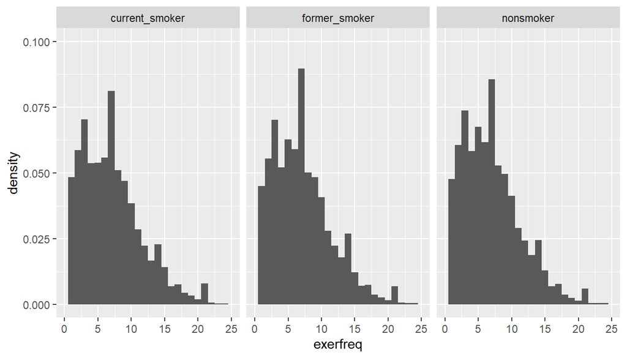

```r
ggplot(data=rq1, mapping=aes(x=exerfreq)) +
  geom_histogram(mapping=aes(y= stat(density)), binwidth=1) +
  facet_grid(~smoker) +
  xlim(c(0, 25)) +
  ylim(c(0, .1))
```

I would expect to see *some* pattern. But surprisingly, these three distributions are almost exactly similar.

If one can conclude anyting from this exploratory data analysis, it’s that smokers, former smokers and nonsmokers get just about the same amount of exercise.

There are many possible improvements that can be done to this analysis, such as weighting types of activity, length of exercise time. Doing this properly could take months of work.

One could also try investigating if there are differences for different genders, age groups, or other demographics. But there is also a danger associated with looking to hard for a pattern. At some point or another, when you divide and break your data enough, you will most likely, by pure chance, find something that looks like a pattern, even if it’s there just by pure chance.

For now, I conclude that when it comes to self-reported physical exercise (times per week), without discriminating between type of activity or exercise time, there seems to be no discernible difference between smokers, former smokers, and nonsmokers, among american adults

**Research quesion 2:**

The dataset contains variables for height and weight, so it would be possible to calculate BMI from those. But the dataset also contains values for BMI, and a variable *_bmi5cat* categorizing into the common 4 category divisions of BMI: underweight, normal weight, overweight, and obese. For simplicity, this variable is used.

For education level, there are two choices, the *educa* variable contains the choices exactly as in the survey. But I decided to use the *educag* which contains slightly fewer categories.

For income level, the survey only reports household income. There is no way of knowing if the income is from the person interviewed, or from their spouse or significant other.

I extract the relevant variables into a dataset *rq2*.

```r
brfss2013 %>%
  select(bmi_cat = X_bmi5cat, edu_level = X_educag, income_level = income2) ->
rq2
```

Let’s inspect the data.

```r
summary(rq2)
```

```
##           bmi_cat                                            edu_level
##  Underweight  :  8267   Did not graduate high school              : 42213
##  Normal weight:154898   Graduated high school                     :142968
##  Overweight   :167084   Attended college or technical school      :134196
##  Obese        :134799   Graduated from college or technical school:170118
##  NA's         : 26727   NA's                                      :  2280
##
##
##             income_level
##  $75,000 or more  :115902
##  Less than $75,000: 65231
##  Less than $50,000: 61509
##  Less than $35,000: 48867
##  Less than $25,000: 41732
##  (Other)          : 87108
##  NA's             : 71426
```

Especially for income level, there’s a large amount of *NA*’s. It’s impossible to know if these missing values are equally distributed among the various income levels, or if they are primarily from the upper or lower income levels.

Let’s drop all *NA*’s:

```r
rq2 <- na.omit(rq2)
summary(rq2)
```

```
##           bmi_cat                                            edu_level
##  Underweight  :  6625   Did not graduate high school              : 31134
##  Normal weight:131392   Graduated high school                     :114093
##  Overweight   :145921   Attended college or technical school      :111481
##  Obese        :119453   Graduated from college or technical school:146683
##
##
##
##             income_level
##  $75,000 or more  :112089
##  Less than $75,000: 62912
##  Less than $50,000: 59261
##  Less than $35,000: 46798
##  Less than $25,000: 39830
##  Less than $20,000: 33105
##  (Other)          : 49396
```

Let’s plot the proportion of each education level for each bmi category.

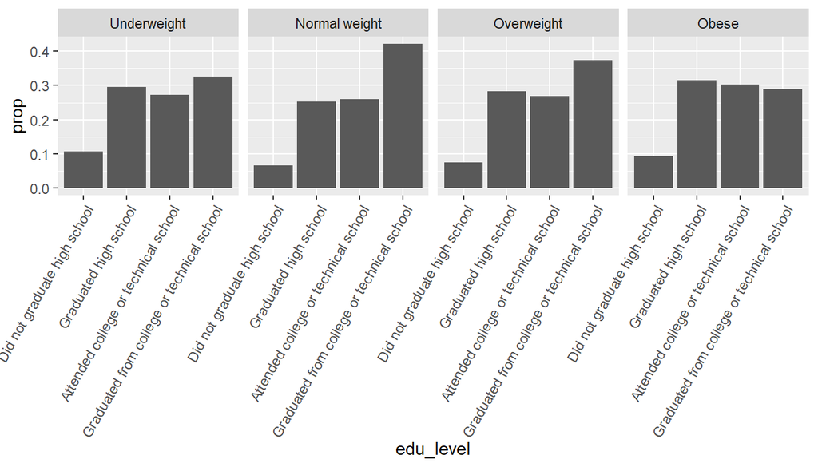

```r
ggplot(data=rq2, mapping=aes(x=edu_level)) +
  geom_bar(mapping=aes(y=..prop.., group=1)) +
  facet_grid(~bmi_cat) +
  theme(axis.text.x = element_text(angle = 60, hjust = 1))
```

People who are normal weight or overweighty seems to be the ones most likely to complete high school, and also the most likely to graduate from college or technical school.

There is no big difference between people who are underweight and people who are obese, but it seems to be that those who are underweight are slightly more likely to graduate from college or technical school.

Now we plot the proportion of people in each income level, for each bmi category.

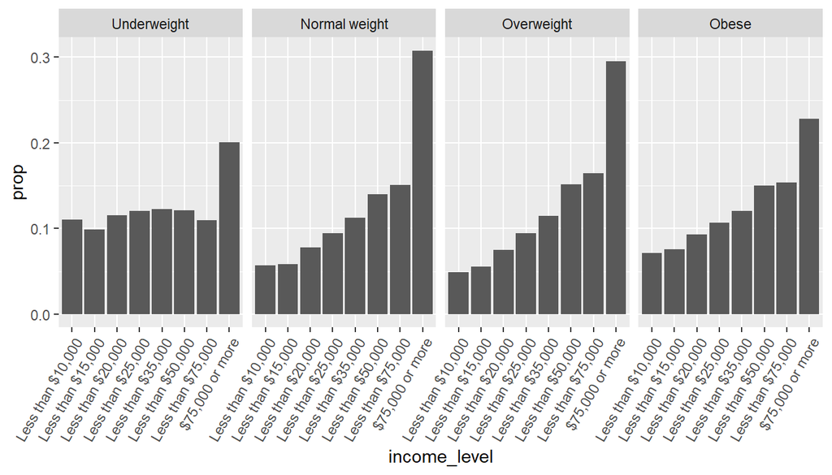

```r
ggplot(data=rq2, mapping=aes(x=income_level)) +
  geom_bar(mapping=aes(y=..prop.., group=1)) +
  facet_grid(~bmi_cat) +
  theme(axis.text.x = element_text(angle = 60, hjust = 1))
```

It seems to be the same trend here. People who are normal or overweight are most likely to have a household income in the top categories.

Underweight people seems much more likely than the other groups to have a low household income.

Conclusion: The original question was if people with high BMI have lower education level or income level? The data does not seem to support that hypothesis. However, it seems reasonable to conclude that people with very high or very low BMI seems to have lower education lever or income level.

As people with low BMI are rarely discriminated against, If I were to make a guess for explaining why we discovered this trend, I would suppose that health reasons, and not discrimination, is the reason why people drop out from education or from the workplace. Note that this is only a guess, and that it is impossible to conclude this based on just the exploratory data analysis done.

**Research quesion 3:**